# Project: Analyze a public dataset

## Influence of the algae on average chlorophyll

When examining the relationship between chlorophyll and the types of algae, only types a1 and a2 show a correlation with chlorophyll. For the other types of algae, the relationship with chlorophyll is either less pronounced or nearly non-existent.

Additionally, the pairplot reveals relationships between different types of algae. The strongest relationship is observed between types a5 and a6, while type a1 exhibits the most correlations with other types of algae.

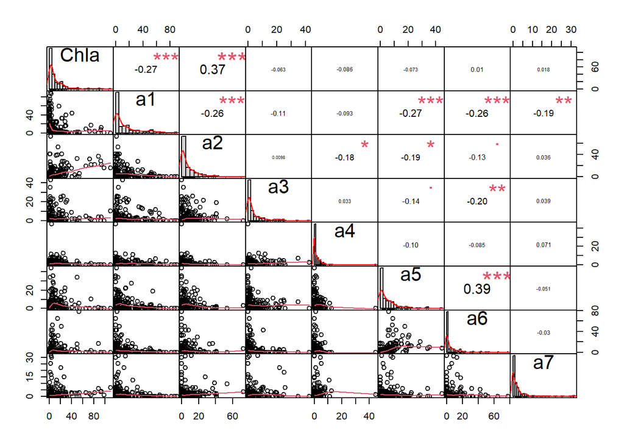

```r
#making a dataframe with only the columns I need
algae.num <- algae_data[,11:18]
#making a paired plot with the other numeric variables
chart.Correlation(algae.num,
                  method = "pearson",
                  histogram = TRUE,
                  pch = 16)
```

## Discussion

First, the comparison between the samples is very difficult because these are samples from different rivers, but the rivers are not mentioned. You have a couple of parameters that you can use to determine the river, like same speed and same size, but then there could be multiple rivers with the same combination in speed and size.

The second thing is that nowhere are the units mentioned in the metadata or description. For example, the minimum oxygen level could suggest that it is in parts per million (ppm), but you cannot be sure.

All of my conclusions are based on the visualizations and are more like assumptions.